# Part_II_Ford GoBike System Data slides

## Investigation Overview

> I wanted to explore at the link between ridesharing time and user gender. I will also consider the time spent on the ridesharing function and the age group of the users.

## Dataset Overview

> The dataset included in this section is the cleaned up version of the dataset utilized in part One.

## (Ride Frequency by Days)

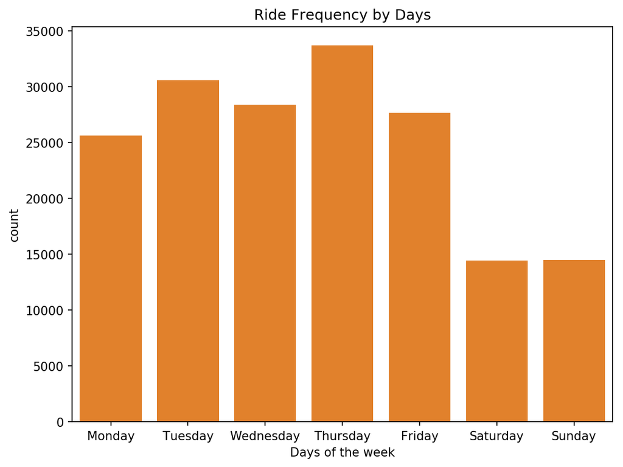

```python
plt.figure(figsize = (8,6),dpi=150)
sns.countplot(data =  fordgobike_df, x = 'start_day', color = sns.color_palette()[1])
plt.xlabel('Days of the week')
plt.title('Ride Frequency by Days');
```

> Most rides were taken on Thursdays and Tuesdays. while Saturday and Sunday have the lowest trip records.

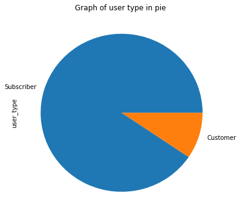

```python
fordgobike_df['user_type'].value_counts().plot(kind='pie', title='Graph of user type in pie ', figsize= (6,6));
```

> The majority of users are subscribers, and only a few fall into the customer category.

#### User Gender Distribution

[figure not shown]

```python
plt.figure(figsize=(10,8),dpi=150)
sns.countplot(data=fordgobike_df,x='duration_sec',hue='member_gender')
plt.xlabel('duration_sec')
plt.ylabel('Count')
plt.legend(title='duration_sec')
plt.title('Gender and duration_sec');
```

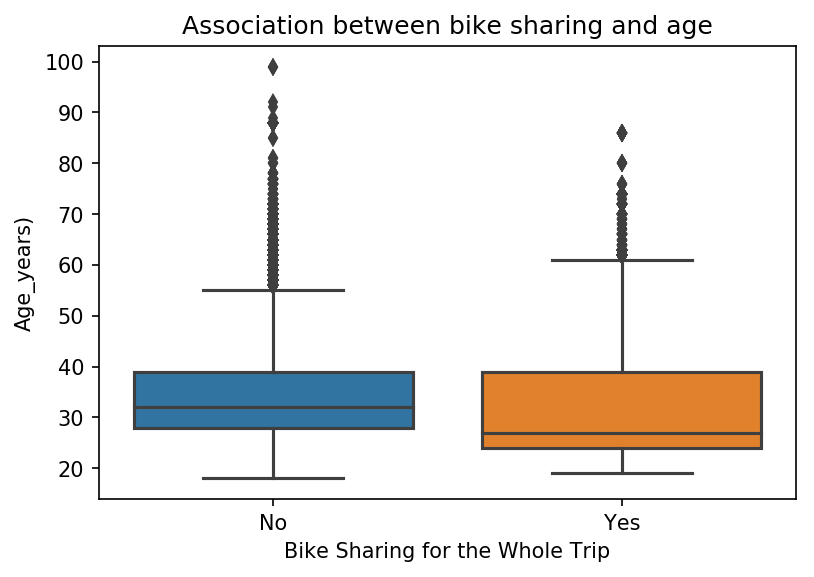

```python
plt.figure(figsize=(6,4),dpi=150)
sns.boxplot(data = fordgobike_df, x = 'bike_share_for_all_trip', y = 'member_age')

plt.xlabel('Bike Sharing for the Whole Trip')
plt.ylabel('Age_years)');
plt.title('Association between bike sharing and age');
```

## (Duration_secend)

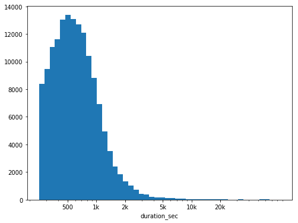

```python
plt.figure(figsize=(8,6),dpi=150)
log_binsize = 0.055
bins = 10 ** np.arange(2.4, np.log10(fordgobike_df['duration_sec'].max())+log_binsize, log_binsize)

plt.figure(figsize=[8, 6])
plt.hist(data = fordgobike_df, x = 'duration_sec', bins = bins)
plt.xscale('log')
plt.xticks([500, 1e3, 2e3, 5e3, 1e4, 2e4], [500, '1k', '2k', '5k', '10k', '20k'])
plt.xlabel('duration_sec');
```

> Duration_sec has a long tail distribution when plotted on a logarithmic scale, the distribution appears skewed to the right and peaks between (500 and 1000).

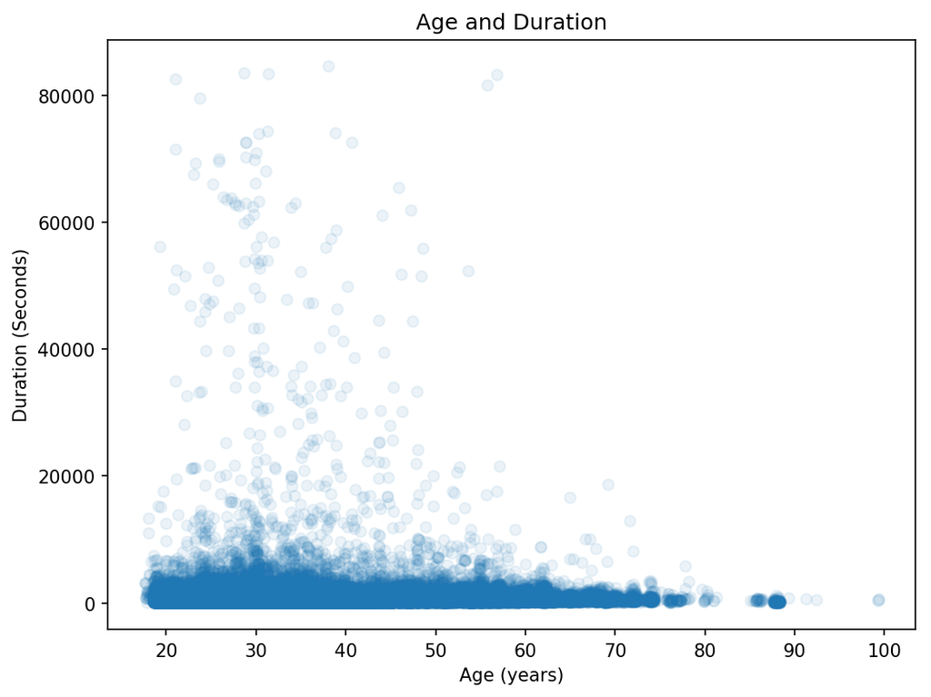

```python
plt.figure(figsize=(8,6),dpi=150)
sns.regplot(data=fordgobike_df,x='member_age',y='duration_sec',fit_reg=False, x_jitter=0.4, scatter_kws={'alpha':1/12})
plt.xlabel('Age (years)')
plt.ylabel('Duration (Seconds)')
plt.title('Age and Duration');
```

> There is a weak negative relationship between duration and age. The older the user, the shorter the travel time.

## Gender and travel duration)

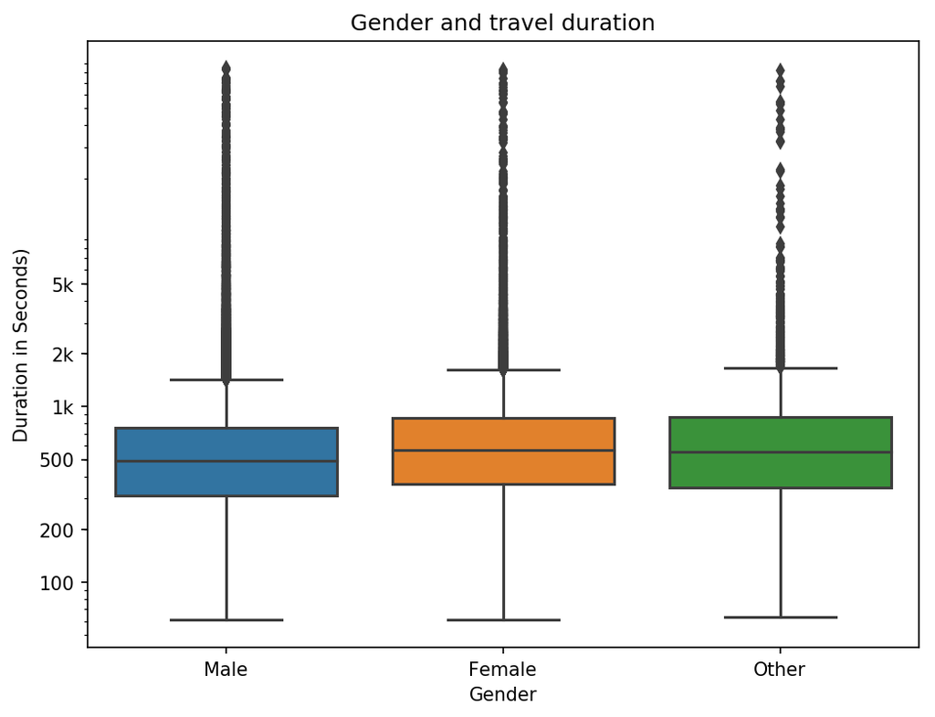

```python
plt.figure(figsize=(8,6),dpi=150)
sns.boxplot(data=fordgobike_df,x='member_gender',y='duration_sec',order=['Male','Female','Other'])
plt.yscale('log')
y_ticklocs=[100,200,500,1e3,2e3,5e3]
y_ticklabels=['100','200','500','1k','2k','5k']
plt.yticks(y_ticklocs,y_ticklabels)
plt.xlabel('Gender')
plt.ylabel('Duration in Seconds)')
plt.title('Gender and travel duration');
```

> The above box plot shows that males have shorter trips than other genders.

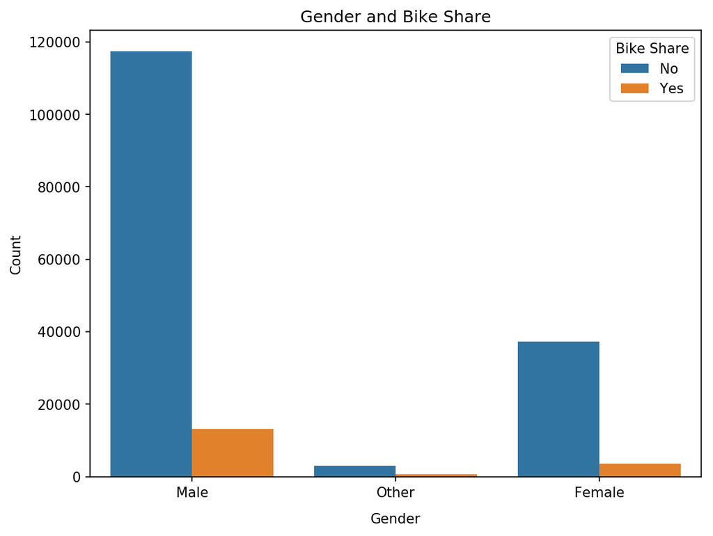

```python
plt.figure(figsize=(8,6),dpi=150)
sns.countplot(data=fordgobike_df,x='member_gender',hue='bike_share_for_all_trip')
plt.xlabel('Gender',labelpad=10)
plt.ylabel('Count')
plt.legend(title='Bike Share')
plt.title('Gender and Bike Share');
```

> There's no apparent relationship between gender and sharing the bike.

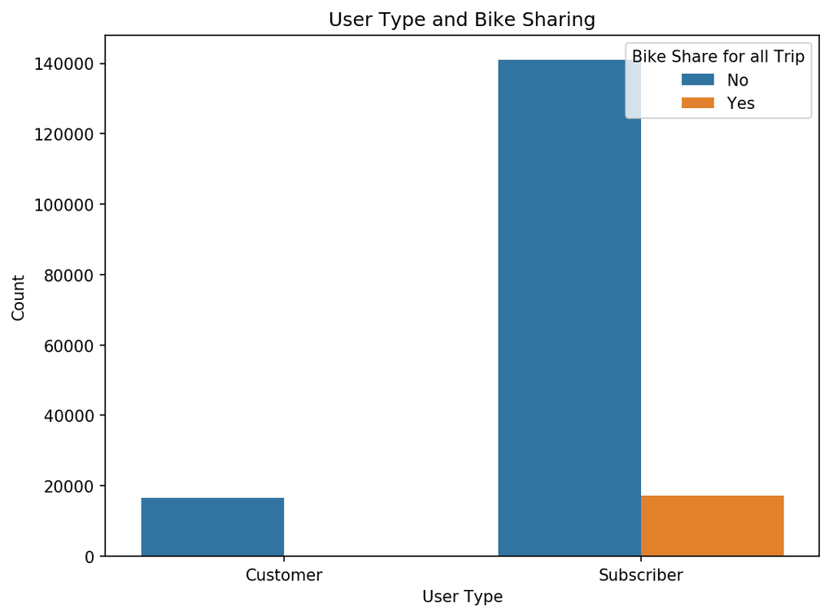

```python
plt.figure(figsize=(8,6),dpi=150)
sns.countplot(data=fordgobike_df,x='user_type',hue='bike_share_for_all_trip')
plt.xlabel('User Type')
plt.ylabel('Count')
plt.legend(title='Bike Share for all Trip')
plt.title('User Type and Bike Sharing');
```

> Bike sharing happens only by subscribers, which is very intuitive.

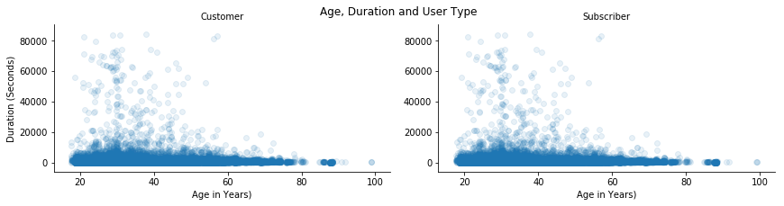

```python
plt.figure(figsize=(10,8),dpi=150)
g=sns.FacetGrid(data=fordgobike_df,col='user_type',aspect=2)
g.map(sns.regplot,data=fordgobike_df, x='member_age',y='duration_sec',fit_reg=False, x_jitter=0.4, scatter_kws={'alpha':1/10})
g.set_titles('{col_name}')
g.set_axis_labels('Age in Years)','Duration (Seconds)')
plt.suptitle('Age, Duration and User Type');
```

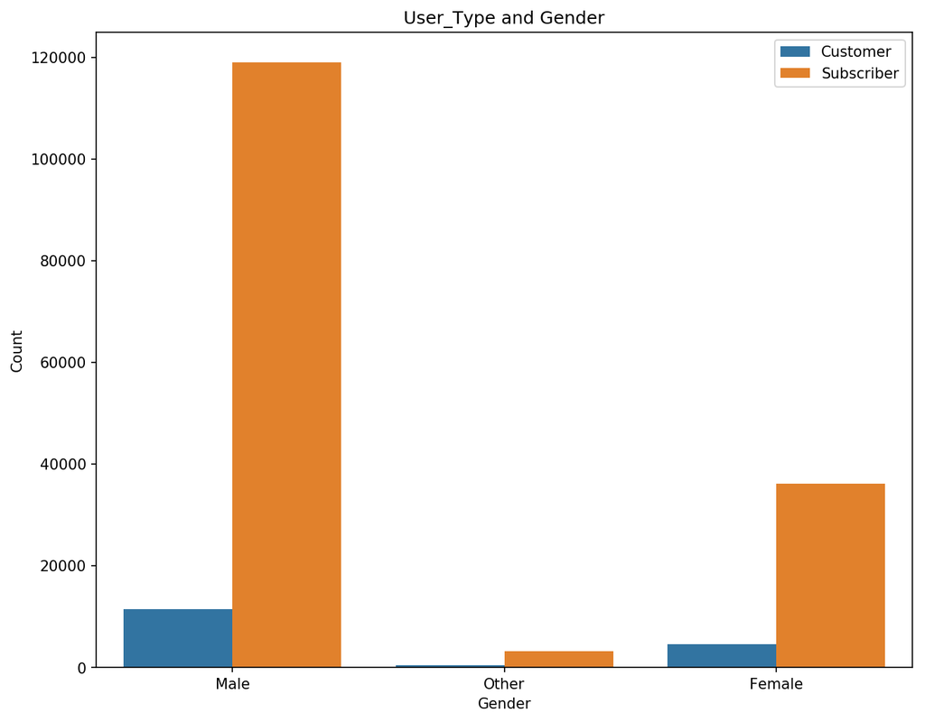

```python
plt.figure(figsize=(10,8),dpi=150)
def plot_x(data, x,hue,x_label, y_label,legend,title):
    sns.countplot(data=data,x=x,hue=hue)
    plt.xlabel('Gender')
    plt.ylabel('Count')
    plt.legend()
    plt.title('User_Type and Gender');

plot_x(data=fordgobike_df, x='member_gender',hue='user_type',x_label='Gender', y_label='Count',legend='user_type',title = 'user_type and gender')
```

> As shown above, subscriber's riders in each gender are more compared to riders who are customer.